# Week 4 Learning Journal

Published

January 31, 2024

## Section 1: Symbolizing Map Layers

Tutorial name(s) and link(s):

[Symbolizing Map Layers](https://www.esri.com/training/catalog/5ca28d18780a171ba3ec188a/symbolizing-map-layers/)

Insight: Appropriate application of symbols and annotation is essential to building a good map that can effectively share the information in your data and provide answers to questions and/or spark meaningful insights.

Screenshot(s):

### Symbolizing Map Layers

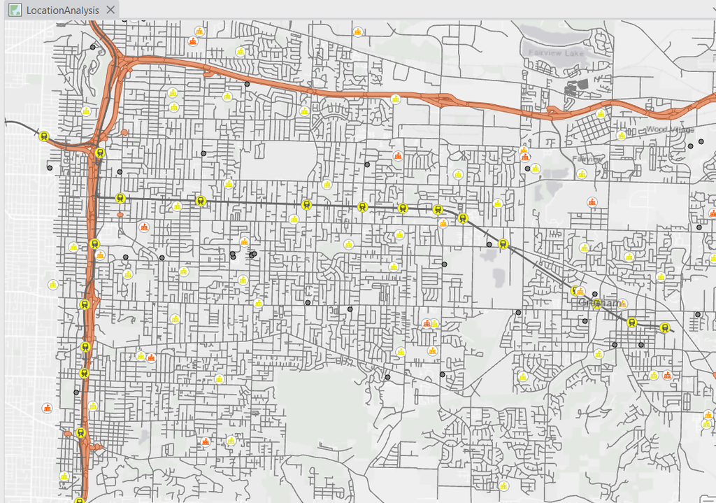

Tutorial results

New Tools and Processes: The goal is to record information on the tools you learned and why that tool was used in the given situation. (The number of new tools and processes you include will change from week to week. Strive to have a minimum of 5; include as many more than 5 as will be helpful to you in the future.)

NEW Tool/Process

Tool/Process Results

Purpose

Describe the results including whether it adds data to the geodatabase. When helpful to you, include a mini-screenshot.

Explain the reason this tool or process was used in this situation.

Nominal

Nominal data contains simple names or categories. It can provide mode but not median or mean.

- Names
- Postal codes
- Land-use codes
- Zoning categories

Ordinal

Ordinal data can be ordered, like low values to high values. It can provide mode and median but not mean.

- Short, medium, tall
- Good, fair, poor

Interval

Interval data has consistent intervals, such as numeric values on a magnitude scale. You can quantify the differences between each value and add or subtract values. There is no true zero. Interval data can provide mode, median, and mean.

- Time
- Elevation
- Temperature

Ratio

Ratio data has all the preceding properties, but, unlike interval data, it has an actual absolute zero. Therefore, you can quantify the differences between values, and you can add, subtract, multiply, or divide values. Ratio data can provide mode, median, and mean.

- Population density
- Annual precipitation
- Crime rate
- Tree heights
- Speed limits

## Section 2: Data Sources

Knowing where to find and download geospatial data can be a big challenge. In this section, list the internet data sources that you use during the semester and any others that you encounter on your own.

- ESRI Tutorial Download

## Section 3: Class How To’s

In this section include documents provided in class (e.g., how to prepare a table for use in GIS, how to georeference) or notes about a specific tool you learn about that’s not part of the assigned topics.